# Analysis of test with partial credit (University of Edinburgh)

George Kinnear

2022-01-12

# 1. Data

Information about the test:

| question | description | MATH_group |
| --- | --- | --- |
| A1 | properties of fractions | A |
| A2 | find intersection of lines | A |
| A3 | composition of functions | B |
| A4 | completing the square | A |
| A5 | trig double angle formula | A |
| A6 | trig wave function | A |
| A7 | graphical vector sum | B |
| A8 | compute angle between 3d vectors | A |
| A9 | simplify logs | A |
| A10 | identify graph of rational functions | B |
| A11 | summing arithmetic progression | A |
| A12 | find point with given slope | A |
| A13 | equation of tangent | A |
| A14 | find minimum gradient of cubic | B |
| A15 | find and classify stationary points of cubic | A |
| A16 | trig chain rule | A |
| A17 | chain rule | A |
| A18 | definite integral | A |
| A19 | area between curve and x-axis (in 2 parts) | B |
| A20 | product rule with given values | B |

Load the student scores for the test:

```r
test_scores %>% skim()
```

Data summary

| Name | Piped data |
| --- | --- |
| Number of rows | 3493 |
| Number of columns | 26 |
| _______________________ |  |
| Column type frequency: |  |
| character | 5 |
| numeric | 21 |
| ________________________ |  |
| Group variables | None |

**Variable type: character**

| skim_variable | n_missing | complete_rate | min | max | empty | n_unique | whitespace |
| --- | --- | --- | --- | --- | --- | --- | --- |
| Start | 2668 | 0.24 | 22 | 24 | 0 | 824 | 0 |
| End | 2668 | 0.24 | 22 | 24 | 0 | 825 | 0 |
| Duration | 2668 | 0.24 | 8 | 23 | 0 | 161 | 0 |
| AnonID | 0 | 1.00 | 5 | 8 | 0 | 3471 | 0 |
| year | 0 | 1.00 | 5 | 5 | 0 | 1 | 0 |

**Variable type: numeric**

| skim_variable | n_missing | complete_rate | mean | sd | p0 | p25 | p50 | p75 | p100 | hist |
| --- | --- | --- | --- | --- | --- | --- | --- | --- | --- | --- |
| A1 | 0 | 1 | 4.25 | 1.51 | 0 | 5.00 | 5.0 | 5.00 | 5 | ▁▁▂▁▇ |
| A2 | 0 | 1 | 4.23 | 1.73 | 0 | 5.00 | 5.0 | 5.00 | 5 | ▁▁▁▁▇ |
| A3 | 0 | 1 | 3.20 | 2.40 | 0 | 0.00 | 5.0 | 5.00 | 5 | ▅▁▁▁▇ |
| A4 | 0 | 1 | 3.67 | 1.56 | 0 | 3.00 | 4.0 | 5.00 | 5 | ▂▂▂▃▇ |
| A5 | 0 | 1 | 3.97 | 2.02 | 0 | 5.00 | 5.0 | 5.00 | 5 | ▂▁▁▁▇ |
| A6 | 0 | 1 | 1.57 | 1.89 | 0 | 0.00 | 0.0 | 2.00 | 5 | ▇▅▁▁▃ |
| A7 | 0 | 1 | 3.45 | 2.24 | 0 | 0.00 | 5.0 | 5.00 | 5 | ▃▁▁▁▇ |
| A8 | 0 | 1 | 3.03 | 2.44 | 0 | 0.00 | 5.0 | 5.00 | 5 | ▅▁▁▁▇ |
| A9 | 0 | 1 | 4.16 | 1.87 | 0 | 5.00 | 5.0 | 5.00 | 5 | ▂▁▁▁▇ |
| A10 | 0 | 1 | 3.14 | 2.08 | 0 | 2.50 | 5.0 | 5.00 | 5 | ▃▁▃▁▇ |
| A11 | 0 | 1 | 3.89 | 1.67 | 0 | 2.50 | 5.0 | 5.00 | 5 | ▁▁▂▁▇ |
| A12 | 0 | 1 | 3.78 | 2.06 | 0 | 4.00 | 5.0 | 5.00 | 5 | ▃▁▁▁▇ |
| A13 | 0 | 1 | 3.53 | 2.05 | 0 | 2.00 | 5.0 | 5.00 | 5 | ▂▂▁▁▇ |
| A14 | 0 | 1 | 2.50 | 1.99 | 0 | 0.00 | 2.0 | 5.00 | 5 | ▇▇▁▁▇ |
| A15 | 0 | 1 | 3.35 | 2.13 | 0 | 1.25 | 5.0 | 5.00 | 5 | ▃▁▂▁▇ |
| A16 | 0 | 1 | 4.23 | 1.81 | 0 | 5.00 | 5.0 | 5.00 | 5 | ▂▁▁▁▇ |
| A17 | 0 | 1 | 4.36 | 1.67 | 0 | 5.00 | 5.0 | 5.00 | 5 | ▁▁▁▁▇ |
| A18 | 0 | 1 | 3.33 | 2.36 | 0 | 0.00 | 5.0 | 5.00 | 5 | ▅▁▁▁▇ |
| A19 | 0 | 1 | 2.33 | 2.49 | 0 | 0.00 | 0.0 | 5.00 | 5 | ▇▁▁▁▇ |
| A20 | 0 | 1 | 1.86 | 2.42 | 0 | 0.00 | 0.0 | 5.00 | 5 | ▇▁▁▁▅ |
| Total | 0 | 1 | 67.83 | 23.04 | 0 | 57.00 | 72.5 | 84.75 | 100 | ▁▁▃▇▇ |

## Cleaning

> **TODO** - filter out “nonserious” attempts

## Data summary

The number of responses from each class:

```r
test_scores %>%
  tally() %>%
  gt() %>%
  data_color(
    columns = c("n"),
    colors = scales::col_numeric(palette = c("Blues"), domain = NULL)
  )
```

| n |
| --- |
| 3493 |

Mean and standard deviation for each item:

```r
test_scores %>%
  select(-Start, -End, -Duration, -AnonID, -Total) %>%
  group_by(year) %>%
  skim_without_charts() %>%
  select(-contains("character."), -contains("numeric.p"), -skim_type) %>%
  rename(complete = complete_rate) %>%
  # make the table wider, i.e. with separate columns for each year's results, with the year at the start of each column name
  pivot_wider(names_from = year, values_from = -c(skim_variable, year), names_glue = "{year}__{.value}") %>%
  # put the columns in order by year
  select(sort(names(.))) %>%
  select(skim_variable, everything()) %>%
  # use GT to make the table look nice
  gt(rowname_col = "skim_variable") %>%
  # group the columns from each year
  tab_spanner_delim(delim = "__") %>%
  fmt_number(columns = contains("numeric"), decimals = 2) %>%
  fmt_percent(columns = contains("complete"), decimals = 0) %>%
  # change all the numeric.mean and numeric.sd column names to Mean and SD
  cols_label(
    .list = test_scores %>% select(year) %>% distinct() %>% transmute(col = paste0(year, "__numeric.mean"), label = "Mean") %>% deframe()
  ) %>%
  cols_label(
    .list = test_scores %>% select(year) %>% distinct() %>% transmute(col = paste0(year, "__numeric.sd"), label = "SD") %>% deframe()
  ) %>%
  data_color(
    columns = contains("numeric.mean"),
    colors = scales::col_numeric(palette = c("Greens"), domain = NULL)
  )
```

|  | 13-16 complete | 13-16 n_missing | 13-16 Mean | 13-16 SD |
| --- | --- | --- | --- | --- |
| A1 | 100% | 0 | 4.25 | 1.51 |
| A2 | 100% | 0 | 4.23 | 1.73 |
| A3 | 100% | 0 | 3.20 | 2.40 |
| A4 | 100% | 0 | 3.67 | 1.56 |
| A5 | 100% | 0 | 3.97 | 2.02 |
| A6 | 100% | 0 | 1.57 | 1.89 |
| A7 | 100% | 0 | 3.45 | 2.24 |
| A8 | 100% | 0 | 3.03 | 2.44 |
| A9 | 100% | 0 | 4.16 | 1.87 |
| A10 | 100% | 0 | 3.14 | 2.08 |
| A11 | 100% | 0 | 3.89 | 1.67 |
| A12 | 100% | 0 | 3.78 | 2.06 |
| A13 | 100% | 0 | 3.53 | 2.05 |
| A14 | 100% | 0 | 2.50 | 1.99 |
| A15 | 100% | 0 | 3.35 | 2.13 |
| A16 | 100% | 0 | 4.23 | 1.81 |
| A17 | 100% | 0 | 4.36 | 1.67 |
| A18 | 100% | 0 | 3.33 | 2.36 |
| A19 | 100% | 0 | 2.33 | 2.49 |
| A20 | 100% | 0 | 1.86 | 2.42 |

# 2. Testing assumptions

Before applying IRT, we should check that the data satisfies the assumptions needed by the model. In particular, to use a 1-dimensional IRT model, we should have some evidence of unidimensionality in the test scores.

### Inter-item correlations

If the test is unidimensional then we would expect student scores on pairs of items to be correlated.

This plot shows the correlations between scores on each pair of items:

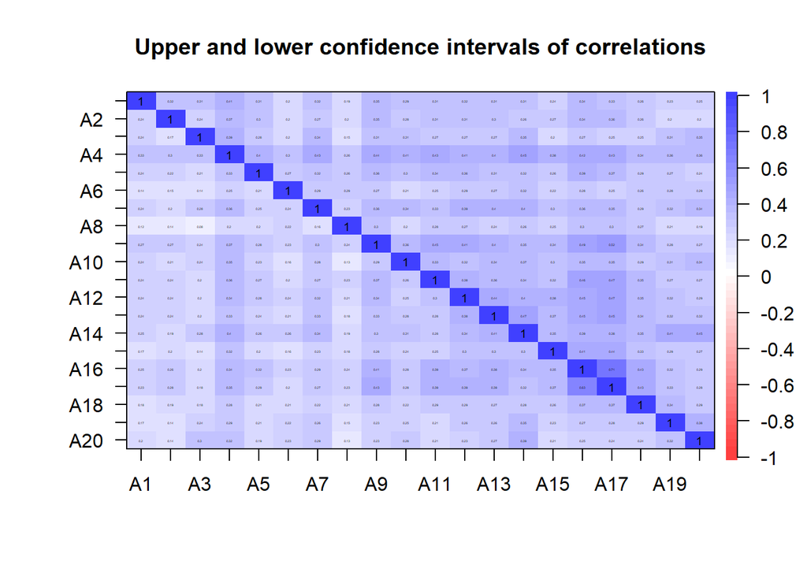

```r
item_scores <- test_scores %>%
  select(starts_with("A"), -AnonID)

cor_ci <- psych::corCi(item_scores, plot = FALSE)

psych::cor.plot.upperLowerCi(cor_ci)
```

Checking for correlations that are not significantly different from 0, there are none:

```r
cor_ci$ci %>%
  as_tibble(rownames = "corr") %>%
  filter(p > 0.05) %>%
  arrange(-p) %>%
  select(-contains(".e")) %>%
  gt() %>%
  fmt_number(columns = 2:4, decimals = 3)
```

| corr | lower | upper | p |
| --- | --- | --- | --- |

The overall picture is that the item scores are well correlated with each other.

### Dimensionality

```r
structure <- check_factorstructure(item_scores)
n <- n_factors(item_scores)
```

#### Is the data suitable for Factor Analysis?

- KMO: The Kaiser, Meyer, Olkin (KMO) measure of sampling adequacy suggests that data seems appropriate for factor analysis (KMO = 0.95).
- Sphericity: Bartlett’s test of sphericity suggests that there is sufficient significant correlation in the data for factor analysis (Chisq(190) = 19571.19, p < .001).

#### Method Agreement Procedure:

The choice of 1 dimensions is supported by 6 (26.09%) methods out of 23 (Acceleration factor, R2, VSS complexity 1, Velicer’s MAP, TLI, RMSEA).

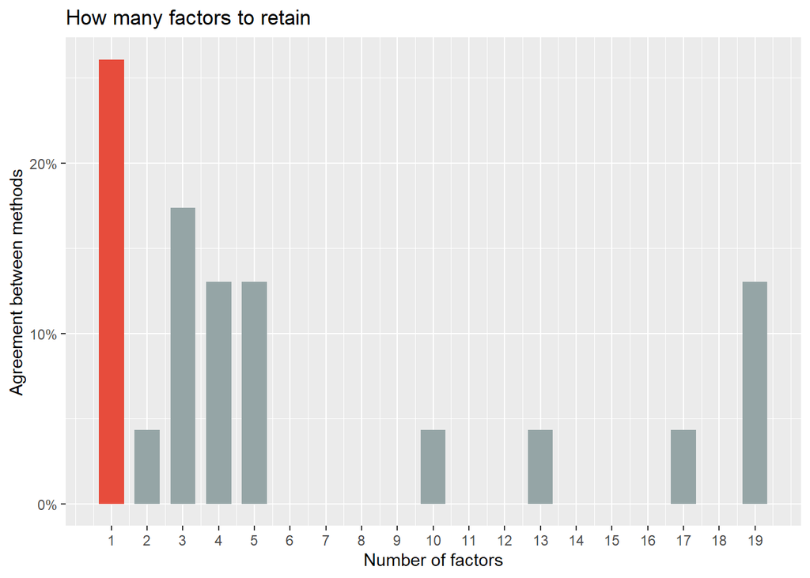

```r
plot(n)
```

```r
summary(n) %>% gt()
```

| n_Factors | n_Methods |
| --- | --- |
| 1 | 6 |
| 2 | 1 |
| 3 | 4 |
| 4 | 3 |
| 5 | 3 |
| 10 | 1 |
| 13 | 1 |
| 17 | 1 |
| 19 | 3 |

```r
#n %>% tibble() %>% gt()
```

```r
pdf(file = "output/uoe_pre_scree.pdf", width = 6, height = 4)
fa.parallel(item_scores, fa = "fa")
```

```
## Parallel analysis suggests that the number of factors =  5  and the number of components =  NA
```

```r
dev.off()
```

### 1 Factor

We use the `factanal` function to fit a 1-factor model.

*Note that this function cannot handle missing data, so any `NA` scores must be set to `0` for this analysis.*

```r
fitfact <- factanal(item_scores,
                    factors = 1,
                    rotation = "varimax")
print(fitfact, digits = 2, cutoff = 0.3, sort = TRUE)
```

```
##
## Call:
## factanal(x = item_scores, factors = 1, rotation = "varimax")
##
## Uniquenesses:
##   A1   A2   A3   A4   A5   A6   A7   A8   A9  A10  A11  A12  A13  A14  A15  A16
## 0.78 0.80 0.80 0.58 0.74 0.83 0.69 0.85 0.61 0.73 0.66 0.63 0.63 0.63 0.72 0.53
##  A17  A18  A19  A20
## 0.52 0.72 0.76 0.76
##
## Loadings:
##  [1] 0.65 0.51 0.55 0.62 0.52 0.58 0.61 0.60 0.61 0.52 0.69 0.69 0.53 0.47 0.45
## [16] 0.44 0.42 0.39 0.49 0.49
##
##                Factor1
## SS loadings       6.02
## Proportion Var    0.30
##
## Test of the hypothesis that 1 factor is sufficient.
## The chi square statistic is 2022.52 on 170 degrees of freedom.
## The p-value is 5.51e-314
```

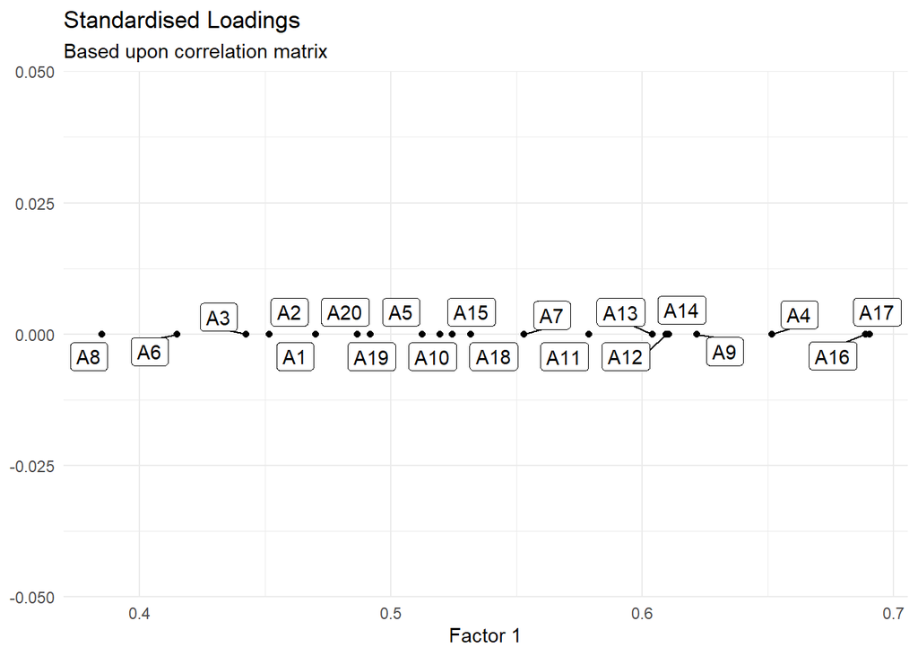

```r
load <- tidy(fitfact)

ggplot(load, aes(x = fl1, y = 0)) +
  geom_point() +
  geom_label_repel(aes(label = paste0("A", rownames(load))), show.legend = FALSE) +
  labs(x = "Factor 1", y = NULL,
       title = "Standardised Loadings",
       subtitle = "Based upon correlation matrix") +
  theme_minimal()
```

```r
load %>%
  select(question = variable, factor_loading = fl1) %>%
  left_join(item_info, by = "question") %>%
  arrange(-factor_loading) %>%
  gt() %>%
  data_color(
    columns = contains("factor"),
    colors = scales::col_numeric(palette = c("Greens"), domain = NULL)
  ) %>%
  data_color(
    columns = contains("MATH"),
    colors = MATH_colours
  )
```

| question | factor_loading | description | MATH_group |
| --- | --- | --- | --- |
| A17 | 0.6903290 | chain rule | A |
| A16 | 0.6887811 | trig chain rule | A |
| A4 | 0.6515326 | completing the square | A |
| A9 | 0.6217907 | simplify logs | A |
| A14 | 0.6105601 | find minimum gradient of cubic | B |
| A12 | 0.6094144 | find point with given slope | A |
| A13 | 0.6041726 | equation of tangent | A |
| A11 | 0.5788227 | summing arithmetic progression | A |
| A7 | 0.5530687 | graphical vector sum | B |
| A18 | 0.5318038 | definite integral | A |
| A15 | 0.5245003 | find and classify stationary points of cubic | A |
| A10 | 0.5196143 | identify graph of rational functions | B |
| A5 | 0.5124303 | trig double angle formula | A |
| A19 | 0.4919597 | area between curve and x-axis (in 2 parts) | B |
| A20 | 0.4867484 | product rule with given values | B |
| A1 | 0.4701486 | properties of fractions | A |
| A2 | 0.4517386 | find intersection of lines | A |
| A3 | 0.4425689 | composition of functions | B |
| A6 | 0.4151131 | trig wave function | A |
| A8 | 0.3852658 | compute angle between 3d vectors | A |

> **TODO** George to add comments here

### 3 Factor

Here we also investigate the 3-factor solution, to see whether these factors are interpretable.

```r
fitfact3 <- factanal(item_scores, factors = 3, rotation = "varimax")
print(fitfact3, digits = 2, cutoff = 0.3, sort = TRUE)
```

```
##
## Call:
## factanal(x = item_scores, factors = 3, rotation = "varimax")
##
## Uniquenesses:
##   A1   A2   A3   A4   A5   A6   A7   A8   A9  A10  A11  A12  A13  A14  A15  A16
## 0.72 0.74 0.73 0.51 0.72 0.81 0.66 0.85 0.58 0.71 0.64 0.64 0.63 0.52 0.72 0.37
##  A17  A18  A19  A20
## 0.30 0.71 0.68 0.63
##
## Loadings:
##     Factor1 Factor2 Factor3
## A16 0.73
## A17 0.79
## A14         0.61
## A19         0.51
## A20         0.57
## A4          0.39    0.53
## A1                  0.46
## A2                  0.42
## A3          0.38    0.35
## A5                  0.40
## A6          0.34
## A7          0.41    0.36
## A8
## A9  0.42            0.44
## A10         0.36    0.34
## A11 0.39            0.40
## A12 0.38    0.33    0.32
## A13 0.38    0.40
## A15 0.39
## A18 0.39    0.32
##
##                Factor1 Factor2 Factor3
## SS loadings       2.61    2.41    2.10
## Proportion Var    0.13    0.12    0.11
## Cumulative Var    0.13    0.25    0.36
##
## Test of the hypothesis that 3 factors are sufficient.
## The chi square statistic is 430.08 on 133 degrees of freedom.
## The p-value is 5.25e-33
```

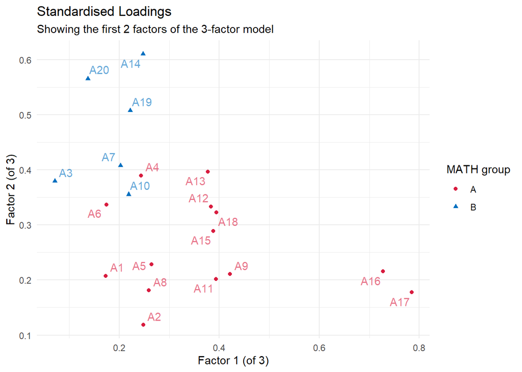

```r
load3 <- tidy(fitfact3)

load3_plot <- load3 %>%
  left_join(item_info, by = c("variable"= "question")) %>%
  ggplot(aes(x = fl1, y = fl2, colour = MATH_group, shape = MATH_group)) +
  geom_point() +
  geom_text_repel(aes(label = paste0("A", rownames(load3))), show.legend = FALSE, alpha = 0.6) +
  labs(
    x = "Factor 1 (of 3)",
    y = "Factor 2 (of 3)"
  ) +
  scale_colour_manual("MATH group", values = MATH_colours) +
  scale_shape_manual(name = "MATH group", values = c(19, 17)) +
  theme_minimal()

load3_plot +
  labs(
    title = "Standardised Loadings",
    subtitle = "Showing the first 2 factors of the 3-factor model"
  )
```

```r
ggsave("output/uoe_3factor.pdf", units = "cm", width = 12, height = 8, dpi = 300,
       plot = load3_plot)
```

```r
main_factors <- load3 %>%
#  mutate(factorNone = 0.4) %>%  # add this to set the main factor to "None" where all loadings are below 0.4
  pivot_longer(names_to = "factor",
               cols = contains("fl")) %>%
  mutate(value_abs = abs(value)) %>%
  group_by(variable) %>%
  top_n(1, value_abs) %>%
  ungroup() %>%
  transmute(main_factor = factor, variable)

library(kableExtra)
load3 %>%
  select(-uniqueness) %>%
  # add the info about which is the main factor
  left_join(main_factors) %>%
  left_join(item_info %>% select(variable = question, description, MATH_group)) %>%
  arrange(main_factor) %>%
  select(main_factor, everything()) %>%
  # arrange adjectives by descending loading on main factor
  rowwise() %>%
  mutate(max_loading = max(abs(c_across(starts_with("fl"))))) %>%
  group_by(main_factor) %>%
  arrange(-max_loading, .by_group = TRUE) %>%
  select(-max_loading) %>%
  # sort out the presentation
  rename("Main Factor" = main_factor, # the _ throws a latex error
         "Question" = variable) %>%
  mutate_at(
    vars(starts_with("fl")),
    ~ cell_spec(round(., digits = 3), bold = if_else(abs(.) > 0.4, T, F))
  ) %>%
  kable(booktabs = T, escape = F, longtable = T) %>%
  kableExtra::collapse_rows(columns = 1, valign = "top") %>%
  kableExtra::kable_styling(latex_options = c("repeat_header"))
```

| Main Factor | Question | fl1 | fl2 | fl3 | description | MATH_group |
| --- | --- | --- | --- | --- | --- | --- |
| fl1 | A17 | 0.785 | 0.178 | 0.235 | chain rule | A |
|  | A16 | 0.727 | 0.216 | 0.243 | trig chain rule | A |
|  | A18 | 0.394 | 0.323 | 0.185 | definite integral | A |
|  | A15 | 0.388 | 0.289 | 0.214 | find and classify stationary points of cubic | A |
|  | A12 | 0.383 | 0.333 | 0.323 | find point with given slope | A |
|  | A8 | 0.259 | 0.181 | 0.212 | compute angle between 3d vectors | A |
| fl2 | A14 | 0.247 | 0.61 | 0.224 | find minimum gradient of cubic | B |
|  | A20 | 0.137 | 0.565 | 0.171 | product rule with given values | B |
|  | A19 | 0.222 | 0.507 | 0.133 | area between curve and x-axis (in 2 parts) | B |
|  | A7 | 0.202 | 0.408 | 0.363 | graphical vector sum | B |
|  | A13 | 0.377 | 0.396 | 0.261 | equation of tangent | A |
|  | A3 | 0.071 | 0.379 | 0.353 | composition of functions | B |
|  | A10 | 0.218 | 0.355 | 0.338 | identify graph of rational functions | B |
|  | A6 | 0.174 | 0.337 | 0.209 | trig wave function | A |
| fl3 | A4 | 0.244 | 0.39 | 0.527 | completing the square | A |
|  | A1 | 0.173 | 0.208 | 0.458 | properties of fractions | A |
|  | A9 | 0.422 | 0.211 | 0.439 | simplify logs | A |
|  | A2 | 0.248 | 0.118 | 0.424 | find intersection of lines | A |
|  | A11 | 0.393 | 0.202 | 0.4 | summing arithmetic progression | A |
|  | A5 | 0.265 | 0.229 | 0.4 | trig double angle formula | A |

> **TODO** George to comment

# 3. Fitting IRT model

> **TODO** - some intro narrative here

```r
fit_gpcm <- mirt(
  data = item_scores, # just the columns with question scores
  model = 1,          # number of factors to extract
  itemtype = "gpcm",  # generalised partial credit model
  SE = TRUE           # estimate standard errors
  )
```

[output not shown]

> **TODO** There are warnings given here about questions being “re-mapped to ensure all categories have a distance of 1”

## Local independence

We compute Yen’s $Q_3$ (1984) to check for any dependence between items after controlling for $\theta$. This gives a score for each pair of items, with scores above 0.2 regarded as problematic (see DeMars, p. 48).

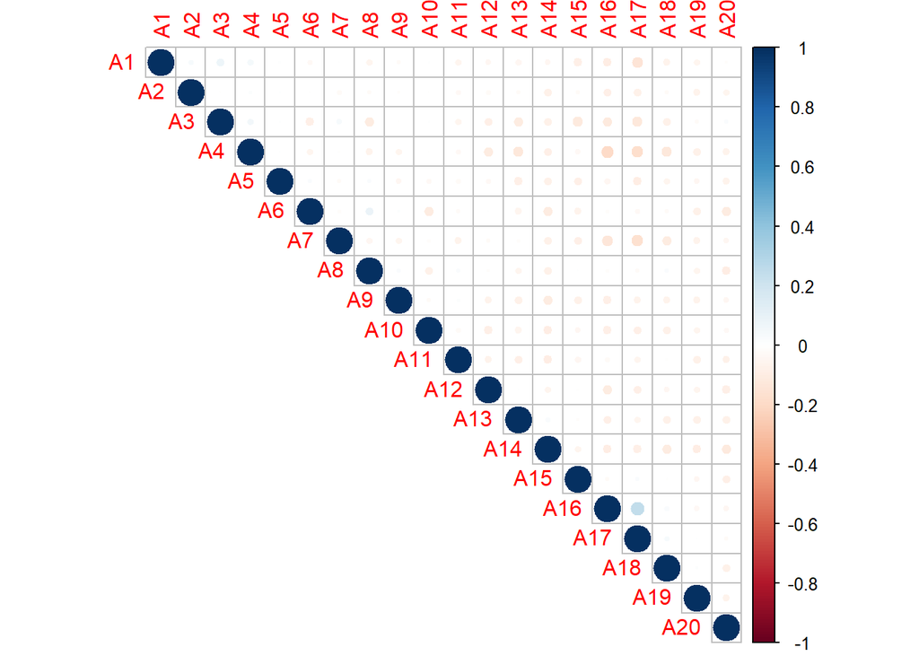

```r
residuals  %>% as.matrix() %>%
  corrplot::corrplot(type = "upper")
```

This shows that most item pairs are independent, with only one pair showing cause for concern:

```r
residuals %>%
  rownames_to_column(var = "item1") %>%
  as_tibble() %>%
  pivot_longer(cols = starts_with("A"), names_to = "item2", values_to = "Q3_score") %>%
  filter(abs(Q3_score) > 0.2) %>%
  filter(parse_number(item1) < parse_number(item2)) %>%
  gt()
```

| item1 | item2 | Q3_score |
| --- | --- | --- |
| A16 | A17 | 0.2472744 |

Items A16 and A17 are on the chain rule (e.g. differentiating $\cos(4x^2+5)$ and $(3x^2-8)^3$ respectively), so it is perhaps unsurprising that students’ performance on these items is not entirely independent.

Given that this violation of the local independence assumption is very mild, we proceed using this model.

## Model parameters

We then compute factor score estimates and augment the existing data frame with these estimates, to keep everything in one place. To do the estimation, we use the `fscores()` function from the mirt package which takes in a computed model object and computes factor score estimates according to the method specified. We will use the EAP method for factor score estimation, which is the “expected a-posteriori” method, the default. We specify it explicitly below, but the results would have been the same if we omitted specifying the method argument since it’s the default method the function uses.

```r
test_scores_with_ability <- test_scores %>%
  mutate(F1 = fscores(fit_gpcm, method = "EAP"))
```

We can also calculate the model coefficient estimates using a generic function `coef()` which is used to extract model coefficients from objects returned by modeling functions. We will set the `IRTpars` argument to `TRUE`, which means slope intercept parameters will be converted into traditional IRT parameters.

```r
coefs_gpcm <- coef(fit_gpcm, IRTpars = TRUE)
```

We use a modified version of the `tidy_mirt_coeffs` function to get all the parameter estimates into a tidy table:

```r
tidy_mirt_coefs <- function(x){
  x %>%
    # melt the list element
    melt() %>%
    # convert to a tibble
    as_tibble() %>%
    # convert factors to characters
    mutate(across(where(is.factor), as.character)) %>%
    # only focus on rows where X2 is a, or starts with b (the parameters in the GPCM)
    filter(X2 == "a" | str_detect(X2, "^b")) %>%
    # in X1, relabel par (parameter) as est (estimate)
    mutate(X1 = if_else(X1 == "par", "est", X1)) %>%
    # turn into a wider data frame
    pivot_wider(names_from = X1, values_from = value) %>%
    rename(par = X2)
}

# use head(., -1) to remove the last element, `GroupPars`, which does not correspond to a question
tidy_gpcm <- map_dfr(head(coefs_gpcm, -1), tidy_mirt_coefs, .id = "Question")
```

```r
tidy_gpcm %>%
  filter(par == "a") %>%
  select(-par) %>%
  rename_with(.fn = ~ paste0("a_", .x), .cols = -Question) %>%
  left_join(
    tidy_gpcm %>%
      filter(str_detect(par, "^b")),
    by = "Question"
  ) %>%
  gt(groupname_col = "Question") %>%
  fmt_number(columns = contains("est|_"), decimals = 3) %>%
  data_color(
    columns = contains("a_"),
    colors = scales::col_numeric(palette = c("Greens"), domain = NULL)
  ) %>%
  data_color(
    columns = c("est", "CI_2.5", "CI_97.5"),
    colors = scales::col_numeric(palette = c("Blues"), domain = NULL)
  ) %>%
  tab_spanner(label = "Discrimination", columns = contains("a_")) %>%
  tab_spanner(label = "Difficulty", columns = c("par", "est", "CI_2.5", "CI_97.5"))
```

| Discrimination a_est | Discrimination a_CI_2.5 | Discrimination a_CI_97.5 | Difficulty par | Difficulty est | Difficulty CI_2.5 | Difficulty CI_97.5 |
| --- | --- | --- | --- | --- | --- | --- |
| A1 |  |  |  |  |  |  |
| 0.8156367 | 0.7345737 | 0.8966997 | b1 | -1.5833336 | -1.78248520 | -1.3841819 |
| 0.8156367 | 0.7345737 | 0.8966997 | b2 | -2.1775681 | -2.41548418 | -1.9396521 |
| A2 |  |  |  |  |  |  |
| 0.6538901 | 0.5869577 | 0.7208224 | b1 | 1.1584913 | 0.78873224 | 1.5282503 |
| 0.6538901 | 0.5869577 | 0.7208224 | b2 | -4.6695571 | -5.20577114 | -4.1333431 |
| A3 |  |  |  |  |  |  |
| 1.2739814 | 1.1518004 | 1.3961624 | b1 | -0.5471744 | -0.62771309 | -0.4666357 |
| A4 |  |  |  |  |  |  |
| 0.6941849 | 0.6372106 | 0.7511591 | b1 | -0.6784674 | -0.97525535 | -0.3816794 |
| 0.6941849 | 0.6372106 | 0.7511591 | b2 | -1.7068513 | -1.98524973 | -1.4284530 |
| 0.6941849 | 0.6372106 | 0.7511591 | b3 | -1.0867022 | -1.29220825 | -0.8811961 |
| 0.6941849 | 0.6372106 | 0.7511591 | b4 | -0.1809733 | -0.34858330 | -0.0133633 |
| 0.6941849 | 0.6372106 | 0.7511591 | b5 | -0.8580443 | -1.03156379 | -0.6845247 |
| A5 |  |  |  |  |  |  |
| 1.4809984 | 1.3390242 | 1.6229726 | b1 | -1.2021123 | -1.30765772 | -1.0965669 |
| A6 |  |  |  |  |  |  |
| 0.5876868 | 0.5293083 | 0.6460654 | b1 | 0.7882934 | 0.62128053 | 0.9553063 |
| 0.5876868 | 0.5293083 | 0.6460654 | b2 | 6.8227954 | 5.86228466 | 7.7833061 |
| 0.5876868 | 0.5293083 | 0.6460654 | b3 | -5.1835952 | -6.12743379 | -4.2397566 |
| A7 |  |  |  |  |  |  |
| 0.9173956 | 0.8345145 | 1.0002767 | b1 | 1.3950176 | 1.13970913 | 1.6503262 |
| 0.9173956 | 0.8345145 | 1.0002767 | b2 | -2.6874930 | -2.99320150 | -2.3817846 |
| A8 |  |  |  |  |  |  |
| 0.9184151 | 0.8183046 | 1.0185256 | b1 | -0.5224816 | -0.62173175 | -0.4232314 |
| A9 |  |  |  |  |  |  |
| 2.1527453 | 1.9457303 | 2.3597603 | b1 | -1.1700338 | -1.25741631 | -1.0826513 |
| A10 |  |  |  |  |  |  |
| 0.9139801 | 0.8332511 | 0.9947091 | b1 | -0.4114932 | -0.52722384 | -0.2957625 |
| 0.9139801 | 0.8332511 | 0.9947091 | b2 | -0.6026455 | -0.72611330 | -0.4791777 |
| A11 |  |  |  |  |  |  |
| 0.5538373 | 0.5051023 | 0.6025723 | b1 | 0.1112890 | -0.27544364 | 0.4980217 |
| 0.5538373 | 0.5051023 | 0.6025723 | b2 | -3.3020567 | -3.69404808 | -2.9100654 |
| 0.5538373 | 0.5051023 | 0.6025723 | b3 | 4.9542880 | 4.22339605 | 5.6851800 |
| 0.5538373 | 0.5051023 | 0.6025723 | b4 | -7.0957195 | -7.94739567 | -6.2440433 |
| A12 |  |  |  |  |  |  |
| 0.7420169 | 0.6748225 | 0.8092113 | b1 | 0.7985413 | 0.52759193 | 1.0694906 |
| 0.7420169 | 0.6748225 | 0.8092113 | b2 | 0.4467941 | 0.13106312 | 0.7625251 |
| 0.7420169 | 0.6748225 | 0.8092113 | b3 | -3.9638527 | -4.41075077 | -3.5169546 |
| A13 |  |  |  |  |  |  |
| 0.7151320 | 0.6521281 | 0.7781358 | b1 | -0.2662849 | -0.44368995 | -0.0888798 |
| 0.7151320 | 0.6521281 | 0.7781358 | b2 | 2.7006159 | 2.25371929 | 3.1475125 |
| 0.7151320 | 0.6521281 | 0.7781358 | b3 | -4.7371275 | -5.29598020 | -4.1782748 |
| A14 |  |  |  |  |  |  |
| 0.7109340 | 0.6513777 | 0.7704903 | b1 | 1.4456464 | 1.16095979 | 1.7303331 |
| 0.7109340 | 0.6513777 | 0.7704903 | b2 | -2.6343051 | -2.92979871 | -2.3388116 |
| 0.7109340 | 0.6513777 | 0.7704903 | b3 | 6.3260715 | 5.39647364 | 7.2556694 |
| 0.7109340 | 0.6513777 | 0.7704903 | b4 | -2.5130191 | -3.36050118 | -1.6655369 |
| 0.7109340 | 0.6513777 | 0.7704903 | b5 | -2.8463131 | -3.26361475 | -2.4290114 |
| A15 |  |  |  |  |  |  |
| 0.3982059 | 0.3615062 | 0.4349056 | b1 | 5.0003793 | 4.23856053 | 5.7621981 |
| 0.3982059 | 0.3615062 | 0.4349056 | b2 | -3.6377919 | -4.28761706 | -2.9879668 |
| 0.3982059 | 0.3615062 | 0.4349056 | b3 | 1.8927989 | 1.39699739 | 2.3886004 |
| 0.3982059 | 0.3615062 | 0.4349056 | b4 | -6.0001038 | -6.70778141 | -5.2924261 |
| A16 |  |  |  |  |  |  |
| 2.8918537 | 2.5887080 | 3.1949994 | b1 | -1.0996616 | -1.17552988 | -1.0237934 |
| A17 |  |  |  |  |  |  |
| 3.0427698 | 2.7107914 | 3.3747482 | b1 | -1.2310414 | -1.31190009 | -1.1501827 |
| A18 |  |  |  |  |  |  |
| 1.5418249 | 1.3994145 | 1.6842353 | b1 | -0.5795490 | -0.65304600 | -0.5060519 |
| A19 |  |  |  |  |  |  |
| 1.7652981 | 1.6048105 | 1.9257858 | b1 | 0.1482212 | 0.09151154 | 0.2049308 |
| A20 |  |  |  |  |  |  |
| 2.1782760 | 1.9761552 | 2.3803968 | b1 | 0.4264383 | 0.37140492 | 0.4814716 |

```r
tidy_gpcm %>%
  write_csv("output/uoe_pre_gpcm-results.csv")
```

> TODO - fix from here onward!

## Information curves

### Test information curve

```r
pdf(file = "output/uoe_pre_info.pdf", width = 6, height = 4)
plot(fit_gpcm, type = "infoSE", main = "Test information")
dev.off()
```

### Item information curves

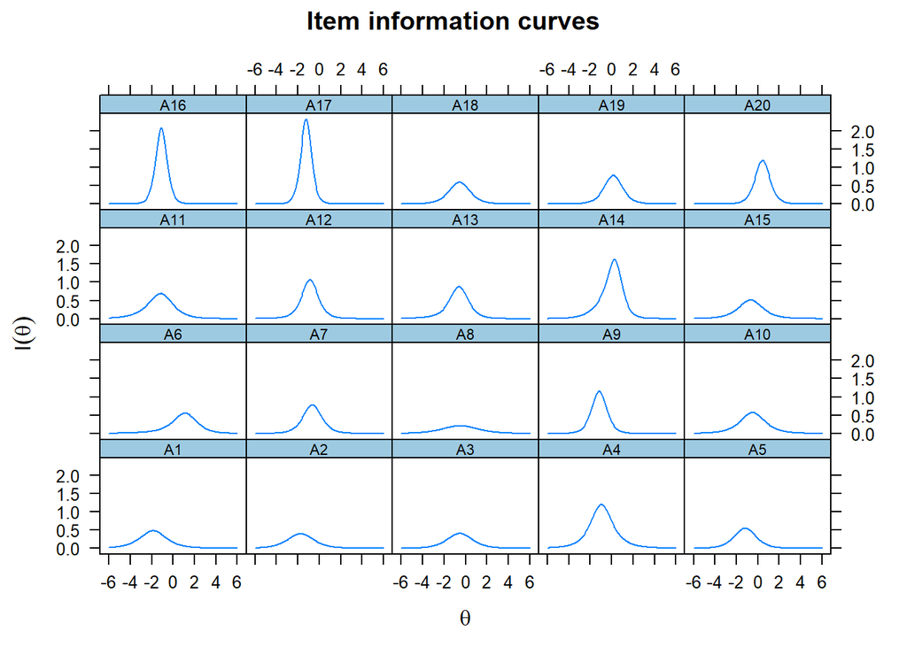

```r
plot(fit_gpcm, type = "infotrace", main = "Item information curves")
```

## Total information

Using `mirt`’s `areainfo` function, we can find the total area under the information curves.

```r
info_gpcm <- areainfo(fit_gpcm, c(-4,4))
info_gpcm %>% gt()
```

| LowerBound | UpperBound | Info | TotalInfo | Proportion | nitems |
| --- | --- | --- | --- | --- | --- |
| -4 | 4 | 39.93097 | 40.80644 | 0.9785458 | 20 |

This shows that the total information in all items is 40.8064385.

## Response curves

### Test response curves

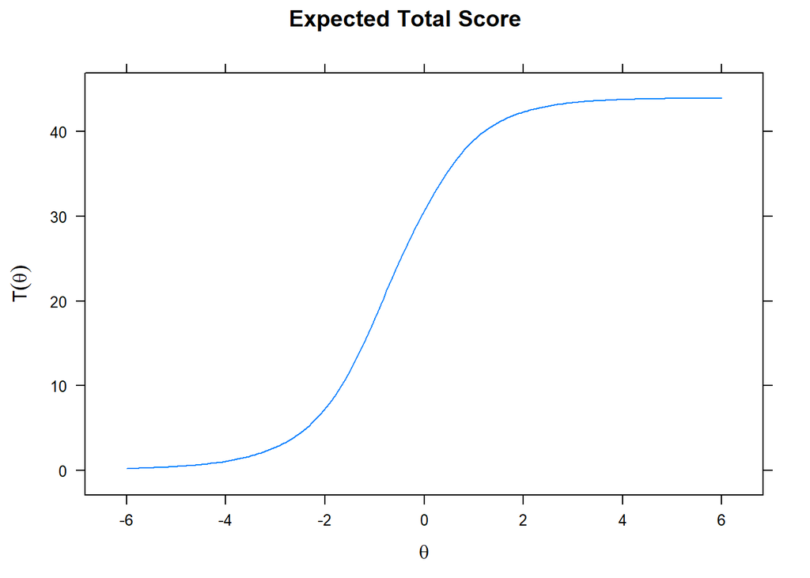

```r
plot(fit_gpcm, type = "score", auto.key = FALSE)
```

### Item response curves

We can get individual item surface and information plots using the `itemplot()` function from the **mirt** package, e.g.

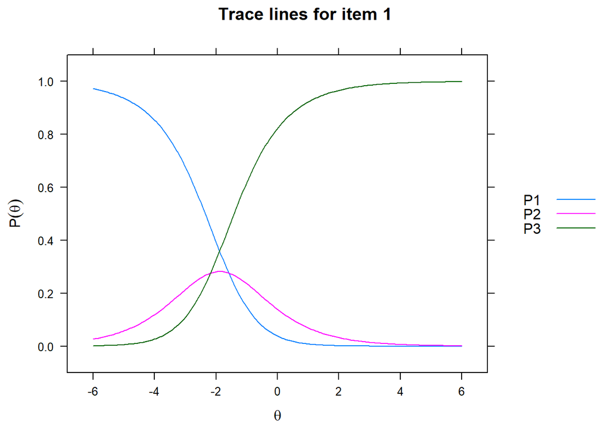

```r
mirt::itemplot(fit_gpcm, item = 1,
               main = "Trace lines for item 1")
```

We can also get the plots for all trace lines, one facet per plot.

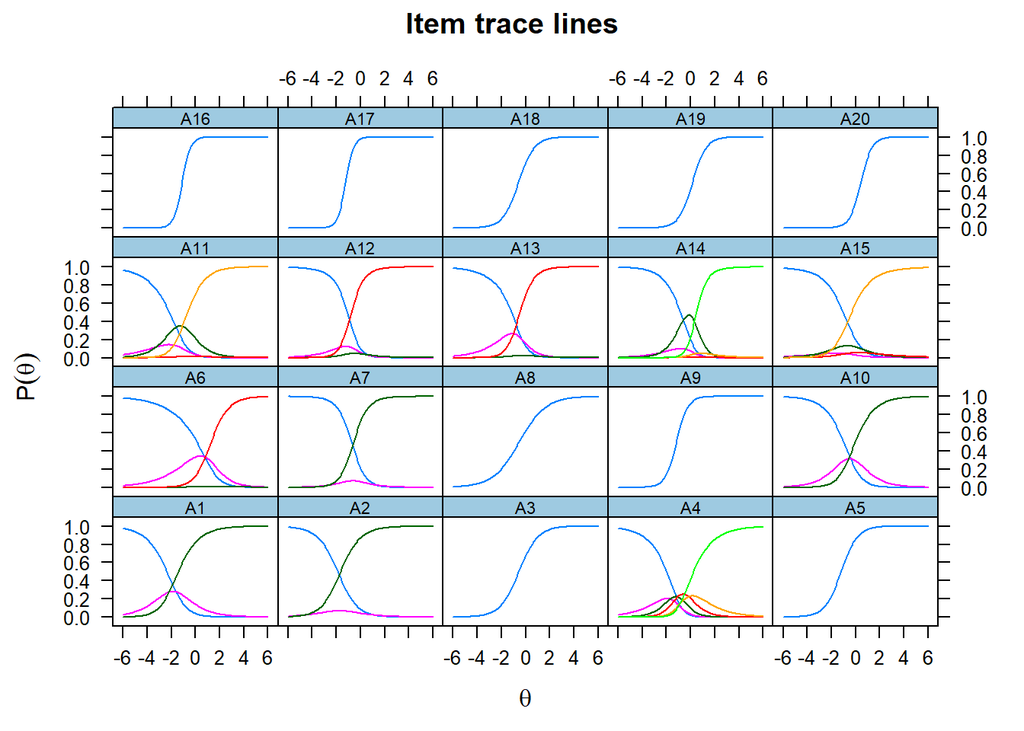

```r
plot(fit_gpcm, type = "trace", auto.key = FALSE)
```

Or all of them overlaid in one plot.

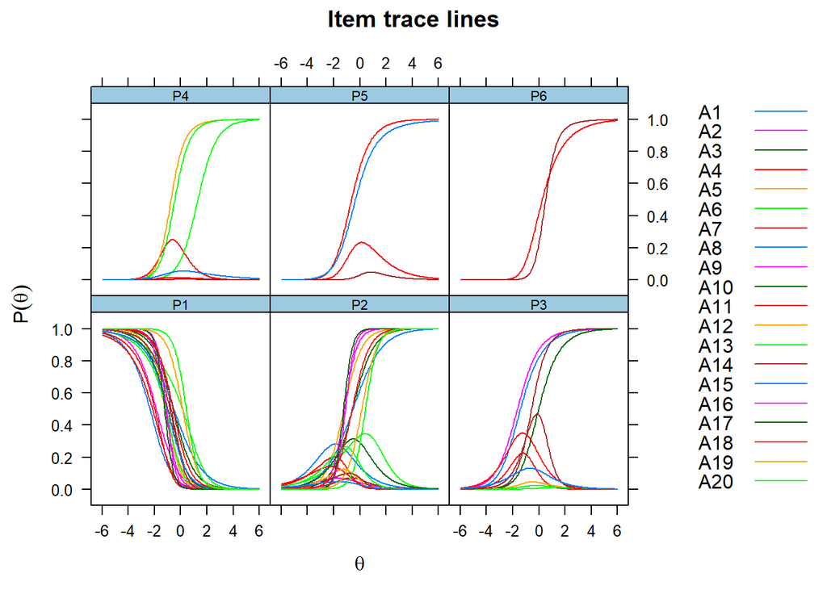

```r
plot(fit_gpcm, type = "trace", facet_items=FALSE)
```

## Packages

In this analysis we used the following packages. You can learn more about each one by clicking on the links below.

- [**mirt**](https://cran.r-project.org/web/packages/mirt/mirt.pdf): For IRT analysis
- [**psych**](https://personality-project.org/r/psych/): For factor analysis
- [**tidyverse**](https://tidyverse.org/): For data wrangling and visualisation
- [**reshape**](http://had.co.nz/reshape/): For reshaping nested lists
- [**vroom**](https://vroom.r-lib.org/): For reading in many files at once
- [**broom**](https://broom.tidymodels.org/): For tidying model output
- [**fs**](https://fs.r-lib.org/): For file system operations
- [**gt**](https://gt.rstudio.com/): For formatting tables
- [**knitr**](https://yihui.org/knitr/): For markdown tables
- [**ggrepel**](https://ggrepel.slowkow.com/): For labelling points without overlap
- [**skimr**](https://docs.ropensci.org/skimr/): For data frame level summary
- [**ggridges**](https://wilkelab.org/ggridges/): For ridge plots